# **Unsupervised Learning Practice Project: Fantasy Sports Clustering Analysis**

## **Hierarchical Clustering**

```python
hc_df = data_pca.copy()
```

```python
# List of distance metrics
distance_metrics = ["euclidean", "chebyshev", "mahalanobis", "cityblock"]

# List of linkage methods
linkage_methods = ["single", "complete", "average", "weighted"]

high_cophenet_corr = 0
high_dm_lm = [0, 0]

for dm in distance_metrics:
    for lm in linkage_methods:
        Z = linkage(hc_df, metric = dm, method = lm)
        c, coph_dists = cophenet(Z, pdist(hc_df))
        print(
            "Cophenetic correlation for {} distance and {} linkage is {}.".format(
                dm.capitalize(), lm, c
            )
        )
        if high_cophenet_corr < c:
            high_cophenet_corr = c
            high_dm_lm[0] = dm
            high_dm_lm[1] = lm

# Printing the combination of distance metric and linkage method with the highest cophenetic correlation
print('*'*100)
print(
    "Highest cophenetic correlation is {}, which is obtained with {} distance and {} linkage.".format(
        high_cophenet_corr, high_dm_lm[0].capitalize(), high_dm_lm[1]
    )
)
```

```
Cophenetic correlation for Euclidean distance and single linkage is 0.8430175514228704.
Cophenetic correlation for Euclidean distance and complete linkage is 0.7412041292261758.
Cophenetic correlation for Euclidean distance and average linkage is 0.8476499945585415.
Cophenetic correlation for Euclidean distance and weighted linkage is 0.8624581351067478.
Cophenetic correlation for Chebyshev distance and single linkage is 0.8381223141111798.
Cophenetic correlation for Chebyshev distance and complete linkage is 0.8028394390632131.
Cophenetic correlation for Chebyshev distance and average linkage is 0.8167064931302251.
Cophenetic correlation for Chebyshev distance and weighted linkage is 0.8448497876639635.
Cophenetic correlation for Mahalanobis distance and single linkage is 0.8065008904132247.
Cophenetic correlation for Mahalanobis distance and complete linkage is 0.6583135946489015.
Cophenetic correlation for Mahalanobis distance and average linkage is 0.7747800632434061.
Cophenetic correlation for Mahalanobis distance and weighted linkage is 0.6486408054242748.
Cophenetic correlation for Cityblock distance and single linkage is 0.8401835511663319.
Cophenetic correlation for Cityblock distance and complete linkage is 0.8241586035407028.
Cophenetic correlation for Cityblock distance and average linkage is 0.8564523087071935.
Cophenetic correlation for Cityblock distance and weighted linkage is 0.8395672301050402.
Highest cophenetic correlation is 0.8624581351067478, which is obtained with Euclidean distance and weighted linkage.
```

**Let's explore different linkage methods with Euclidean distance only.**

```python
# List of linkage methods
linkage_methods = ["single", "complete", "average", "centroid", "ward", "weighted"]

high_cophenet_corr = 0
high_dm_lm = [0, 0]

for lm in linkage_methods:
    Z = linkage(hc_df, metric = "euclidean", method = lm)
    c, coph_dists = cophenet(Z, pdist(hc_df))
    print("Cophenetic correlation for {} linkage is {}.".format(lm, c))
    if high_cophenet_corr < c:
        high_cophenet_corr = c
        high_dm_lm[0] = "euclidean"
        high_dm_lm[1] = lm

# Printing the combination of distance metric and linkage method with the highest cophenetic correlation
print('*'*100)
print(
    "Highest cophenetic correlation is {}, which is obtained with {} linkage.".format(
        high_cophenet_corr, high_dm_lm[1]
    )
)
```

```
Cophenetic correlation for single linkage is 0.8430175514228704.
Cophenetic correlation for complete linkage is 0.7412041292261758.
Cophenetic correlation for average linkage is 0.8476499945585415.
Cophenetic correlation for centroid linkage is 0.8068296032280463.
Cophenetic correlation for ward linkage is 0.577773844586155.
Cophenetic correlation for weighted linkage is 0.8624581351067478.
Highest cophenetic correlation is 0.8624581351067478, which is obtained with weighted linkage.
```

**Let's view the dendrograms for the different linkage methods with Euclidean distance only.**

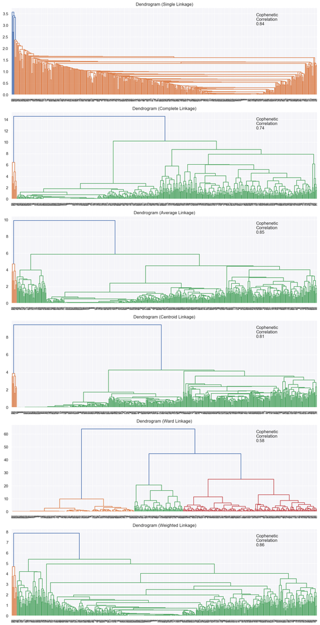

```python
# List of linkage methods
linkage_methods = ["single", "complete", "average", "centroid", "ward", "weighted"]

# Lists to save results of cophenetic correlation calculation
compare_cols = ["Linkage", "Cophenetic Coefficient"]
compare = []

# To create a subplot image
fig, axs = plt.subplots(len(linkage_methods), 1, figsize = (15, 30))

# We will enumerate through the list of linkage methods above
# For each linkage method, we will plot the dendrogram and calculate the cophenetic correlation
for i, method in enumerate(linkage_methods):
    Z = linkage(hc_df, metric = "euclidean", method = method)

    dendrogram(Z, ax = axs[i])
    axs[i].set_title(f"Dendrogram ({method.capitalize()} Linkage)")

    coph_corr, coph_dist = cophenet(Z, pdist(hc_df))
    axs[i].annotate(
        f"Cophenetic\nCorrelation\n{coph_corr:0.2f}",
        (0.80, 0.80),
        xycoords="axes fraction",
    )

    compare.append([method, coph_corr])
```

```python
# Create and print a dataframe to compare cophenetic correlations for different linkage methods
df_cc = pd.DataFrame(compare, columns = compare_cols)
df_cc = df_cc.sort_values(by = "Cophenetic Coefficient")
df_cc
```

|  | Linkage | Cophenetic Coefficient |
| --- | --- | --- |
| 4 | ward | 0.577774 |
| 1 | complete | 0.741204 |
| 3 | centroid | 0.806830 |
| 0 | single | 0.843018 |
| 2 | average | 0.847650 |
| 5 | weighted | 0.862458 |

```python
# Define the hierarchical clustering with average linkage

HCmodel = AgglomerativeClustering(n_clusters = 4, affinity = "euclidean", linkage = "average")
HCmodel.fit(hc_df)
```

```
AgglomerativeClustering(linkage='average', n_clusters=4)
```

```python
# Create a copy of the original data
df3 = df.copy()

# Add hierarchical cluster labels to the Heirarhical and original dataframes
hc_df["HC_segments"] = HCmodel.labels_
df3["HC_segments"] = HCmodel.labels_
```

### **Cluster Profiling**

```python
# Take the cluster-wise mean of all the variables. Hint: First group 'df3' by cluster labels column and then find mean

hc_cluster_profile = df3.groupby("HC_segments").mean()
```

```python
# Create the "count_in_each_segment" column in hierarchical cluster profile

hc_cluster_profile["count_in_each_segment"] = (
    df3.groupby("HC_segments")["Total_Points"].count().values
)
```

```python
# Highlight the maximum average value among all the clusters for each of the variables

hc_cluster_profile.style.highlight_max(color = "lightgreen", axis = 0)
```

| HC_segments | Goals_Scored | Assists | Total_Points | Minutes | Goals_Conceded | Creativity | Influence | Threat | Bonus | Clean_Sheets | count_in_each_segment |
| --- | --- | --- | --- | --- | --- | --- | --- | --- | --- | --- | --- |
| 0 | 0.881517 | 1.139810 | 47.969194 | 1205.945498 | 17.580569 | 148.574408 | 249.536967 | 131.753555 | 3.293839 | 4.182464 | 422 |
| 1 | 16.800000 | 9.200000 | 189.000000 | 3033.200000 | 44.000000 | 494.340000 | 860.720000 | 1591.600000 | 21.800000 | 10.800000 | 5 |
| 2 | 8.565217 | 5.826087 | 129.391304 | 2238.934783 | 29.760870 | 543.273913 | 586.234783 | 861.739130 | 14.021739 | 8.739130 | 46 |
| 3 | 19.333333 | 13.000000 | 238.000000 | 3101.000000 | 37.000000 | 1041.300000 | 1221.000000 | 1294.666667 | 34.000000 | 12.666667 | 3 |

```python
# Print the players in each cluster. Hint: Use the HC_segments feature

for cl in df3["HC_segments"].unique():
    print("In cluster {}, the following players are present:".format(cl))
    print(df3[df3["HC_segments"] == cl]["Player_Name"].unique())
    print()
```

```
In cluster 0, the following players are present:
['Alex Runnarsson' 'Bernd Leno' 'Calum Chambers' 'Cedric Soares'
 'Daniel Ceballos' 'David Luiz' 'Edward Nketiah' 'Emile Smith Rowe'
 'Gabriel Maghalaes' 'Gabriel Teodoro Martinelli Silva' 'Granit Xhaka'
 'Hector Bellerin' 'Kieran Tierney' 'Martin Odegaard' 'Matt Macey'
 'Miguel Azeez' 'Mohamed Naser El Sayed Elneny' 'Pablo Mari'
 'Reiss Nelson' 'Rob Holding' 'Sead Kolasinac' 'Shkodran Mustafi'
 'Sokratis Papastathopoulos' 'Thomas Partey' 'William Saliba'
 'Willian Borges Da Silva' 'Ahmed El Mohamady' 'Carney Chukwuemeka'
 'Conor Hourihane' 'Douglas Luiz Soares de Paulo' 'Emiliano Martinez'
 'Ezri Konsa Ngoyo' 'Henri Lansbury' 'Jacob Ramsey'
 'Jaden Philogene-Bidace' 'John McGinn' 'Jose Peleteiro Romallo'
 'Keinan Davis' 'Kortney Hause' 'Mahmoud Ahmed Ibrahim Hassan'
 'Marvelous Nakamba' 'Matt Targett' 'Matthew Cash' 'Morgan Sanson'
 'Orjan Nyland' 'Ross Barkley' 'Tyrone Mings' 'Wesley Moraes'
 'Aaron Connolly' 'Adam Lallana' 'Adam Webster' 'Alexis Mac Allister'
 'Alireza Jahanbakhsh' 'Andi Zeqiri' 'Ben White'
 'Bernardo Fernandes da Silva Junior' 'Dan Burn' 'Davy Propper'
 'Jakub Moder' 'Jason Steele' 'Jayson Molumby' 'Joel Veltman'
 'Jose Izquierdo' 'Lewis Dunk' 'Mathew Ryan' 'Percy Tau' 'Reda Khadra'
 'Robert Sanchez' 'Solomon March' 'Steven Alzate' 'Tariq Lamptey'
 'Yves Bissouma' 'Anthony Driscoll-Glennon' 'Ashley Barnes'
 'Ashley Westwood' 'Bailey Peacock-Farrell' 'Ben Mee' 'Charlie Taylor'
 'Dale Stephens' 'Dwight McNeil' 'Erik Pieters' 'Jack Cork'
 'James Tarkowski' 'Jay Rodriguez' 'Jeff Hendrick' 'Jimmy Dunne'
 'Joel Mumbongo' 'Johann Berg Gudmundsson' 'Josh Benson' 'Josh Brownhill'
 'Kevin Long' 'Lewis Richardson' 'Matej Vydra' 'Matthew Lowton'
 'Nick Pope' 'Phil Bardsley' 'Robbie Brady' 'Will Norris'
 'Andreas Christensen' 'Antonio Rudiger' 'Benjamin Chilwell'
 'Billy Gilmour' 'Callum Hudson-Odoi' 'Cesar Azpilicueta'
 'Christian Pulisic' 'Edouard Mendy' 'Emerson Palmieri dos Santos'
 'Faustino Anjorin' 'Fikayo Tomori' 'Hakim Ziyech'
 'Jorge Luiz Frello Filho' 'Kai Havertz' 'Karlo Ziger' 'Kepa Arrizabalaga'
 'Kurt Zouma' 'Marcos Alonso' 'Mateo Kovacic' "N'Golo Kante"
 'Olivier Giroud' 'Reece James' 'Tammy Abraham' 'Thiago Silva'
 'Valentino Livramento' 'Willy Caballero' 'Andros Townsend'
 'Cheikhou Kouyate' 'Connor Wickham' 'Eberechi Eze' 'Gary Cahill'
 'Jack Butland' 'Jairo Riedewald' 'James McArthur' 'James McCarthy'
 'James Tomkins' 'Jean-Philippe Mateta' 'Jeffrey Schlupp' 'Joel Ward'
 'Jordan Ayew' 'Luka Milivojevic' 'Mamadou Sakho' 'Martin Kelly'
```

[output cut: 80 more lines]

```
 'Richarlison de Andrade' 'Jack Harrison' 'Raphael Dias Belloli'
 'Rodrigo Moreno' 'Stuart Dallas' 'Harvey Barnes' 'James Maddison'
 'Kelechi Iheanacho' 'Roberto Firmino' 'Sadio Mane'
 'Gabriel Fernando de Jesus' 'Ilkay Gundogan' 'Kevin De Bruyne'
 'Phil Foden' 'Raheem Sterling' 'Riyad Mahrez' 'Edinson Cavani'
 'Marcus Rashford' 'Mason Greenwood' 'Callum Wilson' 'Che Adams'
 'Danny Ings' 'Gareth Bale' 'Jarrod Bowen' 'Jesse Lingard'
 'Michail Antonio' 'Pablo Fornals' 'Tomas Soucek' 'Pedro Lomba Neto']

In cluster 1, the following players are present:
['Ollie Watkins' 'Dominic Calvert-Lewin' 'Patrick Bamford' 'Jamie Vardy'
 'Mohamed Salah']

In cluster 3, the following players are present:
['Bruno Fernandes' 'Harry Kane' 'Heung-Min Son']
```

**We see that most of the players have been grouped into one cluster, and there are two very sparse clusters. This clustering does not look good as the clusters do not have enough variability.**

**Let us try using Ward linkage as it has more distinct and separated clusters (as seen from it's dendrogram before). 4 appears to be a good number of clusters from the dendrogram for Ward linkage.**

```python
# Define the hierarchical clustering with Ward Linkage

HCmodel = AgglomerativeClustering(n_clusters = 4, affinity = "euclidean", linkage = "ward")
HCmodel.fit(hc_df)
```

```
AgglomerativeClustering(n_clusters=4)
```

```python
# Create a copy of the original data
df3 = df.copy()

# Add hierarchical cluster labels to the Heirarhical and original dataframes
hc_df["HC_segments"] = HCmodel.labels_
df3["HC_segments"] = HCmodel.labels_
```